# Fifteen years of extensive and inadvertent elasmobranch trade in Brazil detected by DNA tools

Codes and Plots R Markdown

2023-09-10

# Overview

This R Markdown file contains all codes for literature collection and main data analysis performed in the paper “Fifteen years of extensive and inadvertent elasmobranch trade in Brazil detected by DNA tools”. Codes are broken into chunks pertaining each type of analysis and/or plot. Any question regarding the code listed here should be sent to #email1# and #email2#

## Packages and Options

For literature curation, the packages `bibliometrix`, `irr`, and `openxlsx` were utilized. For all the remaining data analysis, `Tidyverse` was the package utilized, with plots being generated via the `ggplot2` package. The packages `ggpubr`, `ggrepel`, and `ggspatial` were used in complement to `ggplot2`.

There are 7 color palettes used for all 6 figures. They are listed in the block below.

```r
library(tidyverse)
library(ggpubr)
library(ggrepel)
library(ggspatial)

pal_pink <- c("#C994C8", "#E063AF", "#CD397B")
pal_reds <- c("#FFFFB2", "#FECC5C", "#FD8D3C", "#E31A1C", "#7f7f7f")
pal_iucn <- c(
  "#DB070F", "#D0D0C6", "#FF7A48", "#5FC564", "grey55", "#CEE14A",
  "#FDE646", "#545454"
)
pal_st_chg <- c("#DB070F", "#FF7A48", "#5FC564", "#CEE14A", "#FDE646")
pal_st_dd <- c("grey55", "#FF7A48", "#5FC564", "#CEE14A", "#FDE646")
pal_threat <- c(
  "#DB070F", "#FF7B47", "#FDE744", "#CFE248",
  "#5EC764", "#D1D1C7", "#545454"
)

pal_br_threat <- c(
  "#DB070F", "#FF7B47", "#FDE744", "#FF4416", "#FF972A",
  "#D1D1C7", "#369584", "#365896", "#343434"
)
```

# Data collection and cleaning operations (dataset creation)

1. Perform extensive search on databases Scopus (https://www.scopus.com/) and Web of Science (https://www.webofscience.com/). You can choose other databases.  
   1.1. Keywords and Boolean operators: (“mis*label*” OR “misidentification” OR “molecular tool*” OR ”genetics tool*” OR “DNA tool*” OR ”DNA barcod*” OR “forens* genetic*” OR ”genetic* forens*” OR ”molecular identification” OR ”genetic* identification” OR “forens* identification”) AND (“elasmobranch*” OR ”shark*” OR “ray*” OR ”guitar*fish*” OR ”stingray*” OR “skate*” OR ”skateray*”) AND NOT (“x*ray” OR ”radiation” OR ”radiograph*” OR “Ray* fluid” OR “integrative taxonomy”).  
   1.2. You can also add filters if you want, I applied three: (i) research performed in Brazil, (ii) published until 2021 December 31st, and (iii) research paper.  
   1.3. Export your searchers as bibtex (.bib)
2. Polish your data with Bibliometrix  
   2.1. Import your data

Import .bib results to Bibliometrix

```r
library(bibliometrix)
file1 <- "WoS.bib"
W <- convert2df(file1, dbsource = "wos", format = "bibtex")
head(W["TC"]) #TC is the number of citations

file2 <- "scopus.bib"
S <- convert2df(file2, dbsource = "scopus", format = "bibtex")
head(S["TC"])

# Merge results from both searches and remove the duplicate papers
data <- mergeDbSources(W, S, remove.duplicated = TRUE)
head(data["TC"]) #check results - head w/ citations number
View(data) #check results - visualize your data
dim(data) #check results - dimension of your database

# Export to excel format
library(openxlsx)
write.xlsx(data, file = 'data.xlsx')
```

This excel file contains all the papers retrieved from Scopus and Web of Science. You can proceed for the next step, or you can search for additional data on Scholar and manually add to this spreadsheet (recommended). I added the first 50 hits of the Scholar search with the following Boolean operators: Brazil (shark OR ray OR guitarfish OR stingray OR skate) AND mislabel* OR forensic OR genetics OR “molecular identification”

2.2 Clean your data Check data file and inspect abstracts to make sure if all papers retrieved are in the context of your analysis. It is also important to look to the complete record in this step. To ensure reliability of data collection, it is important that more than one author participate in the process of data cleaning. Here, three authors participated. Each author check the spreadhseet alone and we just merged the data earlier, as you can check in this excel file (data-WS-curation-IB_MA_VP). From this file, we created a matrix marking the acceptance and rejection of each paper by each author (MatrixIRR.xlsx).

2.3. Calculate the Inter Rater Agreement

The matrix created in the previous step will be used to calculate the Fleiss’s Kappas Index Fleiss Kappas Index is an index of interrater agreement between m raters on categorical data, where a reliable data collection has a kappa index > 0.8

- IRR for the boolean search on both Scopus and Web of Science

```r
library(irr)
matrix_ws <- readxl::read_xlsx("../data/MatrixIRR.xlsx", sheet="wosco", col_names = TRUE)
str(matrix_ws)
```

```
## tibble [62 × 3] (S3: tbl_df/tbl/data.frame)
##  $ MA : chr [1:62] "yes" "yes" "yes" "yes" ...
##  $ VPC: chr [1:62] "yes" "yes" "yes" "yes" ...
##  $ IB : chr [1:62] "yes" "yes" "yes" "no" ...
```

```r
#The null hypothesis Kappa=0
kappam.fleiss(matrix_ws)
```

```
##  Fleiss' Kappa for m Raters
##
##  Subjects = 62
##    Raters = 3
##     Kappa = 0.871
##
##         z = 11.9
##   p-value = 0
```

```r
kappam.fleiss(matrix_ws, exact = TRUE)
```

```
##  Fleiss' Kappa for m Raters (exact value)
##
##  Subjects = 62
##    Raters = 3
##     Kappa = 0.871
```

```r
kappam.fleiss(matrix_ws, detail = TRUE)
```

```
##  Fleiss' Kappa for m Raters
##
##  Subjects = 62
##    Raters = 3
##     Kappa = 0.871
##
##         z = 11.9
##   p-value = 0
##
##      Kappa      z p.value
## no   0.871 11.878   0.000
## yes  0.871 11.878   0.000
```

Kappa = 0.871

- IRR for the search on Scholar

```r
library(irr)
matrix_s<-readxl::read_xlsx("../data/MatrixIRR.xlsx", sheet="scholar", col_names = TRUE)
str(matrix_s)
```

```
## tibble [50 × 3] (S3: tbl_df/tbl/data.frame)
##  $ MA : chr [1:50] "no" "yes" "no" "no" ...
##  $ VPC: chr [1:50] "no" "no" "no" "no" ...
##  $ IB : chr [1:50] "no" "no" "no" "no" ...
```

```r
#The null hypothesis Kappa=0
kappam.fleiss(matrix_s)
```

```
##  Fleiss' Kappa for m Raters
##
##  Subjects = 50
##    Raters = 3
##     Kappa = 0.916
##
##         z = 11.2
##   p-value = 0
```

```r
kappam.fleiss(matrix_s, exact = TRUE)
```

```
##  Fleiss' Kappa for m Raters (exact value)
##
##  Subjects = 50
##    Raters = 3
##     Kappa = 0.916
```

```r
kappam.fleiss(matrix_s, detail = TRUE)
```

```
##  Fleiss' Kappa for m Raters
##
##  Subjects = 50
##    Raters = 3
##     Kappa = 0.916
##
##         z = 11.2
##   p-value = 0
##
##      Kappa      z p.value
## no   0.916 11.216   0.000
## yes  0.916 11.216   0.000
```

Kappa = 0.916

- IRR for the searches in all databases (combining Scopus + Web of Science + Scholar)

```r
library(irr)
matrix_t<-readxl::read_xlsx("../data/MatrixIRR.xlsx", sheet="all", col_names = TRUE)
str(matrix_t)
```

```
## tibble [112 × 3] (S3: tbl_df/tbl/data.frame)
##  $ MA : chr [1:112] "yes" "yes" "yes" "yes" ...
##  $ VPC: chr [1:112] "yes" "yes" "yes" "yes" ...
##  $ IB : chr [1:112] "yes" "yes" "yes" "no" ...
```

```r
#The null hypothesis Kappa=0
kappam.fleiss(matrix_t)
```

```
##  Fleiss' Kappa for m Raters
##
##  Subjects = 112
##    Raters = 3
##     Kappa = 0.903
##
##         z = 16.5
##   p-value = 0
```

```r
kappam.fleiss(matrix_t, exact = TRUE)
```

```
##  Fleiss' Kappa for m Raters (exact value)
##
##  Subjects = 112
##    Raters = 3
##     Kappa = 0.903
```

```r
kappam.fleiss(matrix_t, detail = TRUE)
```

```
##  Fleiss' Kappa for m Raters
##
##  Subjects = 112
##    Raters = 3
##     Kappa = 0.903
##
##         z = 16.5
##   p-value = 0
##
##      Kappa      z p.value
## no   0.903 16.543   0.000
## yes  0.903 16.543   0.000
```

Kappa = 0.903

# Data Cleaning Routines (main datasets)

Typical data cleaning routines were applied to the main datasets: `01a_raw_data` and `01b_raw_mt_data`. Cases were changed to lower when needed, special characters used in column names changed to underscore, and species names were separated by single space instead of underscore.

```r
# Load datasets
raw_data <- readxl::read_xlsx("../data/01a_raw_data.xlsx", sheet = "Trade_Analysis")
raw_mt_data <- readxl::read_xlsx("../data/01b_raw_mt_data.xlsx", sheet = 3)

## Change case to lower
raw_data <- raw_data %>% rename_all(., .funs = tolower) # column names

raw_data <- raw_data %>%
  mutate(state = case_when(
    state == "AMAPÁ" ~ "Amapá", # change specific values
    state == "PARÁ" ~ "Pará",
    TRUE ~ state
  ))

raw_mt_data <- raw_mt_data %>% rename_all(., .funs = tolower)

## Change dots/spaces for underscore (column names)
raw_mt_data <- raw_mt_data %>% rename_all(~ str_replace_all(., " ", "_"))

## Remove underscore from data
raw_data <- raw_data %>%
  mutate_all(~ str_replace_all(., "_", " "))

raw_mt_data <- raw_mt_data %>%
  mutate_all(~ str_replace_all(., "_", " "))

# Export clean datasets
write.csv(raw_data, "../data/02a_clean_data.csv", row.names = FALSE)
write.csv(raw_mt_data, "../data/02b_clean_mt_data.csv", row.names = FALSE)
```

# Data Analysis

Standard frequency statistics (e.g. counts, percentages) were applied to different datasets produced at the end of the cleaning process.

```r
# Load clean datasets
clean_data <- read.csv("../data/02a_clean_data.csv")
clean_mt_data <- read.csv("../data/02b_clean_mt_data.csv")
clean_mol_data <- read.csv("../data/02c_clean_gen_data.csv")

## Simple counts
by_year <- clean_data %>%
  group_by(year = publication_date) %>%
  summarise(paper_count = n_distinct(paper)) %>%
  drop_na()

by_state <- clean_data %>%
  group_by(state = state) %>%
  summarise(sample_count = n()) %>%
  arrange(desc(sample_count))

## Filter uncertain data
filter_rows <- c(3, 8, 10, 13, 14) # rows with uncertain values

by_state <- by_state %>%
  filter(!row_number() %in% filter_rows) %>%
  mutate(sample_count = case_when(
    sample_count == 1012 ~ 1022,
    TRUE ~ sample_count
  )) %>%
  arrange(desc(sample_count))

## Create abbreviation and region columns
by_state <- by_state %>%
  mutate(
    abbrev = c(
      "PA", "SP", "RN", "PR", "RJ", "SC", "RS",
      "AP", "BA", "SE", "CE", "PE", "AL", "ES", "MA"
    ),
    region = c(
      "North", "Southeast", "North", "South", "Southeast",
      "South", "South", "North", "Northeast", "Northeast",
      "Northeast", "Northeast", "Northeast", "Southeast",
      "Northeast"
    )
  ) %>%
  relocate(c(abbrev, region), .before = sample_count)

# Count papers by state

## Define states and abbreviation vectors
states <- c(
  "Pará", "São Paulo", "Rio Grande do Norte", "Paraná", "Rio de Janeiro",
  "Santa Catarina", "Rio Grande do Sul", "Amapá", "Bahia",
  "Sergipe", "Ceará", "Pernambuco", "Alagoas", "Espirito Santo", "Maranhão"
)

abbrev <- c(
  "PA", "SP", "RN", "PR", "RJ", "SC", "RS", "AP", "BA", "SE",
  "CE", "PE", "AL", "ES", "MA"
)

## Filter data and count papers by state
papers_by_state <- clean_data %>%
  filter(state %in% states) %>%
  select(paper, state, region) %>%
  distinct() %>%
  group_by(state, region) %>%
  summarize(paper_count = n()) %>%
  arrange(desc(paper_count)) %>%
  mutate(abbrev = abbrev[match(state, states)], .before = region)
# Export new datasets
write.csv(by_year, "../data/03a_papers_by_year.csv", row.names = FALSE)
write.csv(by_state, "../data/04_samples_by_state.csv", row.names = FALSE)
write.csv(papers_by_state, "../data/05_papers_by_state.csv", row.names = FALSE)
```

Since the meat trade is an important part of the discussion of the paper, analysis regarding this topic were conducted in separate from the main data.

```r
# Paper classification

## Define paper class vector
p_class <- c("Methodology", "Trade analysis", "Methodology/Trade analysis")

## Filter data and count paper classes by year
classes_by_year <- clean_mt_data %>%
  filter(paper_category %in% p_class) %>%
  select(title, year, paper_category) %>%
  distinct() %>%
  group_by(year, paper_category) %>%
  summarize(paper_count = n())
## Calculate percents by paper type
percents <- clean_mt_data %>%
  group_by(paper_category) %>%
  summarise(paper_count = n()) %>%
  mutate(type_percent = round(paper_count / sum(paper_count) * 100, digits = 1))

# Export new datasets
write.csv(classes_by_year, "../data/03b_paper_class_by_year.csv", row.names = FALSE)
write.csv(percents, "../data/06_paper_class_percent.csv", row.names = FALSE)
```

The same principle was applied to analyse and quantify the genetic tools used to identify species presented in the papers retrieved.

```r
# DNA techniques
dna_data <- clean_data %>%
  select(publication_date, paper, dna_technique) %>%
  distinct() %>%
  drop_na()

## Define DNA techniques vector
dna_tech <- c("DNA sequencing", "PCR Multiplex", "PCR RFLP")

## Filter data and count DNA techniques by year
tech_by_year <- dna_data %>%
  filter(dna_technique %in% dna_tech) %>%
  select(paper, publication_date, dna_technique) %>%
  distinct() %>%
  group_by(publication_date, dna_technique) %>%
  summarize(tech_count = n())
# Export dataset
write.csv(tech_by_year, "../data/07_techs_by_year.csv", row.names = FALSE)
```

Shark and Ray datasets were analysed in separate. Molecular data (i.e. types of markers presented by the papers) used to identify each species were quantified and analysed.

```r
# Molecular Data

## Isolate shark and ray data
shark_data <- clean_mol_data %>%
  filter(classification %in% "shark") %>%
  select(
    species, genbank_total, marker_coi, marker_cytb, marker_12s, marker_16s,
    marker_nadh2, marker_its2, marker_mitogenome, marker_bold_coi
  ) %>%
  mutate_all(~ replace_na(., 0))

ray_data <- clean_mol_data %>%
  filter(classification %in% "ray") %>%
  select(
    species, genbank_total, marker_coi, marker_cytb, marker_12s, marker_16s,
    marker_nadh2, marker_its2, marker_mitogenome, marker_bold_coi
  ) %>%
  mutate_all(~ replace_na(., 0))

## Define molecular markers vector
markers <- grep("marker", colnames(shark_data), value = TRUE)

## Calculate percentage of species with sequences for each marker
shark_mk_percent <- round(colSums(shark_data[markers] > 0) / nrow(shark_data) * 100, 1)
ray_mk_percent <- round(colSums(ray_data[markers] > 0) / nrow(ray_data) * 100, 1)

## Combine data into a single dataframe
marker_percent <- data.frame(
  marker = markers,
  shark = shark_mk_percent,
  ray = ray_mk_percent
)

marker_percent <- marker_percent %>% # long format
  pivot_longer(
    cols = c("shark", "ray"),
    names_to = "species",
    values_to = "percent"
  )

# Export dataset
write.csv(marker_percent, "../data/08_marker_percent.csv", row.names = FALSE)
```

# Figure 1

Figure 1 is based on the dataset `02b_clean_mt_data` which contains data relevant to the meat trade analysis. Data was summarised to obtain:

- the **number of papers** for the 2008-2021 period, **based on paper classification**.
- the **frequency** of each paper category.

```r
# Load dataset
clean_mt_data <- read.csv("../data/02b_clean_mt_data.csv")
```

```r
# Summarise
ptypes_by_year <- clean_mt_data %>%
  group_by(year = year, paper_class = paper_category) %>%
  summarise(paper_count = n_distinct(title)) %>%
  drop_na()
ptypes_percent <- clean_mt_data %>%
  group_by(paper_category) %>%
  summarise(paper_count = n()) %>%
  mutate(
    percent = round(paper_count / 35 * 100, digits = 1),
    lab_pos = cumsum(percent) - .5 * percent
  ) %>%
  arrange(desc(percent))
```

The two plots from Figure 1 are then created separately:

```r
# Grouped bars plot
ptypes_bars <- ptypes_by_year %>%
  ggplot(aes(fill = paper_class, y = paper_count, x = year)) +
  geom_bar(position = "stack", stat = "identity") +
  scale_x_continuous(
    limits = c(2007, 2022),
    breaks = seq(2008, 2021, by = 1),
    expand = c(0, 0)
  ) +
  scale_y_continuous(
    limits = c(0, 10),
    breaks = seq(0, 10, by = 2),
    expand = c(0, 0)
  ) +
  scale_fill_discrete(type = pal_pink) +
  labs(x = "\nYear", y = "Number of papers\n") +
  theme_minimal() +
  theme(
    panel.grid.major = element_blank(),
    panel.grid.minor = element_blank(),
    axis.line = element_line(color = "black"),
    axis.ticks = element_line(color = "black"),
    axis.title = element_text(face = "bold", size = 18, family = "Times New Roman"),
    axis.text = element_text(size = 13, family = "Times New Roman", color = "black"),
    legend.position = "none",
    plot.margin = margin(0.5, 0.5, 0.5, 0.5, unit = "cm")
  )
```

```r
# Donut plot

## Adjust donut label position
ptypes_percent <- ptypes_percent %>%
  mutate(
    lab_pos = replace(lab_pos, lab_pos == 65.8, 33.5),
    lab_pos = replace(lab_pos, lab_pos == 11.45, 87.5),
    lab_pos = replace(lab_pos, lab_pos == 27.2, 73.5)
  )

# Create plot
ptypes_donut <- ggplot(
  ptypes_percent, aes(x = 2, percent, fill = paper_category)
) +
  geom_bar(stat = "identity") +
  geom_label_repel(
    aes(
      y = lab_pos,
      label = paste(percent, "%", sep = "")
    ),
    min.segment.length = 0,
    direction = "both",
    nudge_x = 0.5,
    nudge_y = 1,
    size = 5,
    family = "Times New Roman",
    fontface = "bold",
    show.legend = FALSE
  ) +
  coord_polar("y", start = 700) +
  xlim(.2, 2.5) +
  scale_fill_discrete(type = pal_pink) +
  labs(fill = "  Paper \nCategory") +
  guides(fill = guide_legend(nrow = 3, byrow = TRUE)) +
  theme_minimal() +
  theme(
    panel.grid.major = element_blank(),
    panel.grid.minor = element_blank(),
    axis.line = element_blank(),
    axis.ticks = element_blank(),
    axis.title = element_blank(),
    axis.text = element_blank(),
    legend.title = element_text(face = "bold", size = 14, family = "Times New Roman"),
    legend.text = element_text(size = 14, family = "Times New Roman"),
    legend.position = "bottom"
  )
```

Then Figure 1 composition is created:

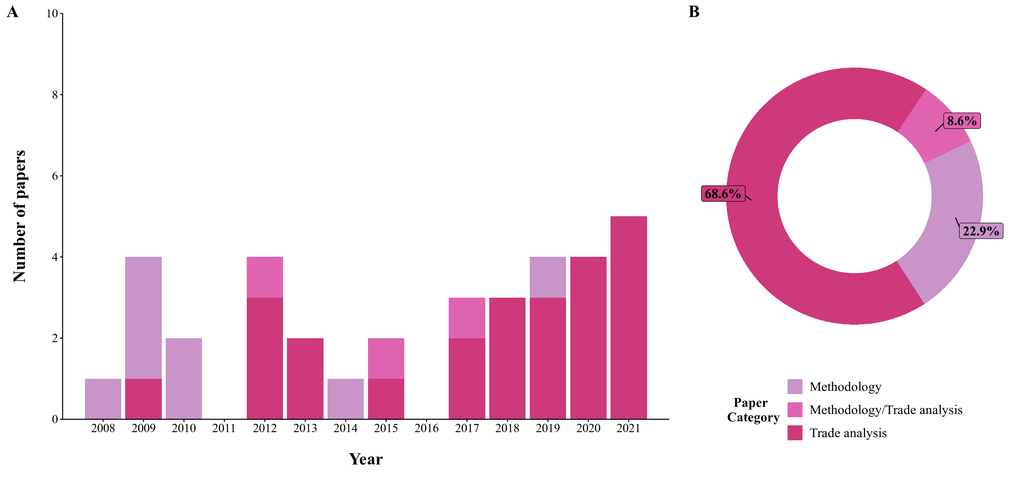

```r
ptypes_comp <- ggarrange(ptypes_bars, ptypes_donut,
  ncol = 2, labels = c("A", "B"),
  font.label = list(size = 18, family = "Times New Roman"),
  widths = c(2, 1)
)

plot(ptypes_comp)
```

# Figure 2

In Figure 2, **Plot A** is a representation of Brazilian states, derived from `geobr` package. **Plot B** and **Plot C** are created from the datasets `04_samples_by_state` and `05_papers_by_state`, respectively.

```r
# Load datasets
state_samples <- read.csv("../data/04_samples_by_state.csv")
state_papers <- read.csv("../data/05_papers_by_state.csv")
```

The first plot in Figure 2 is the states map of Brazil:

```r
# Create new dataframe for the map
br <- geobr::read_state(
  year = 2020,
  showProgress = FALSE
)
```

```
## Using year 2020
```

```r
states_df <- state_samples
states_df <- br %>%
  left_join(states_df, by = c("name_state" = "state"))

# Map plot
state_map <- ggplot(
  states_df, aes(fill = sample_count)
) +
  geom_sf(lwd = 0.1, color = "black") +
  geom_sf_text(aes(label = abbrev),
    size = 3, fontface = "bold", family = "Times New Roman",
    fun.geometry = sf::st_centroid
  ) +
  scale_fill_gradient(
    low = "#E31A1C",
    high = "#FFFFB2",
    name = "Total count",
    na.value = "grey85"
  ) +
  coord_sf() +
  annotation_scale(
    height = unit(0.25, "cm"),
    style = "ticks"
  ) +
  annotation_north_arrow(
    location = "bl", which_north = "true",
    pad_x = unit(0.7, "cm"),
    pad_y = unit(1, "cm"),
    style = north_arrow_minimal(),
    height = unit(1, "cm"),
    width = unit(1, "cm")
  ) +
  labs(x = "Longitude", y = "Latitude") +
  theme_minimal() +
  theme(
    panel.grid.major = element_blank(),
    panel.grid.minor = element_blank(),
    legend.position = "none",
    axis.title = element_blank(),
    axis.text = element_blank(),
    plot.margin = margin(0.5, 0, 0.5, 0, "cm")
  )
```

To create **barplots in B and C**, the **x axis** is then standardized:

```r
x_limits <- c(
  "PA", "SP", "RN", "PR", "RJ", "SC", "RS", "AP", "BA", "SE", "CE",
  "PE", "AL", "ES", "MA"
)
```

And then plots are drawn based on 1) the number of samples per state and 2) the number of papers by state:

```r
# Samples by state
state_samples_plot <- state_samples %>%
  mutate(abbrev = fct_reorder(abbrev, sample_count, .desc = TRUE)) %>%
  ggplot(aes(abbrev, sample_count)) +
  geom_bar(stat = "identity", aes(fill = sample_count)) +
  geom_text(aes(label = sample_count),
    vjust = -0.2,
    size = 4,
    family = "Times New Roman",
    fontface = "bold"
  ) +
  scale_fill_gradient(low = "#E31A1C", high = "#FFFFB2", name = "Total count") +
  scale_y_continuous(
    limits = c(0, 1200),
    breaks = seq(0, 1200, by = 200),
    expand = c(0, 0)
  ) +
  labs(x = "\nBrazilian State", y = "Number of Samples\n") +
  theme_minimal() +
  theme(
    panel.grid.major = element_blank(),
    panel.grid.minor = element_blank(),
    legend.position = "none",
    axis.line = element_line(color = "black"),
    axis.ticks = element_line(color = "black"),
    axis.title = element_text(face = "bold", size = 16),
    axis.text.x = element_text(size = 12, color = "black"),
    axis.text.y = element_text(size = 14, color = "black"),
    text = element_text(family = "Times New Roman"),
    plot.margin = margin(0.5, 0, 0.5, 0, "cm")
  )

# Papers by state
state_papers_plot <- state_papers %>%
  mutate(abbrev = fct_reorder(abbrev, paper_count, .desc = TRUE)) %>%
  ggplot(aes(abbrev, paper_count)) +
  geom_bar(stat = "identity", aes(fill = paper_count)) +
  geom_text(aes(label = paper_count),
    vjust = -0.2,
    size = 4,
    family = "Times New Roman",
    fontface = "bold"
  ) +
  scale_fill_gradient(low = "#E31A1C", high = "#FFFFB2", name = "Total count") +
  scale_x_discrete(limits = x_limits) +
  scale_y_continuous(
    limits = c(0, 12),
    breaks = seq(0, 12, by = 2),
    expand = c(0, 0)
  ) +
  labs(x = "\nBrazilian State", y = "Number of Papers\n") +
  theme_minimal() +
  theme(
    panel.grid.major = element_blank(),
    panel.grid.minor = element_blank(),
    legend.position = "none",
    axis.line = element_line(color = "black"),
    axis.ticks = element_line(color = "black"),
    axis.title = element_text(face = "bold", size = 16),
    axis.text.x = element_text(size = 12, color = "black"),
    axis.text.y = element_text(size = 14, color = "black"),
    text = element_text(family = "Times New Roman"),
    plot.margin = margin(0.5, 0, 0.5, 0, "cm")
  )
```

Finally, Figure 2 complete composition is achieved:

```r
map_comp <- ggarrange(state_map, state_samples_plot, state_papers_plot,
  ncol = 3,
  widths = c(1, 1, 1), labels = c("A", "B", "C"),
  font.label = list(size = 18, family = "Times New Roman")
)
```

```
## Scale on map varies by more than 10%, scale bar may be inaccurate
```

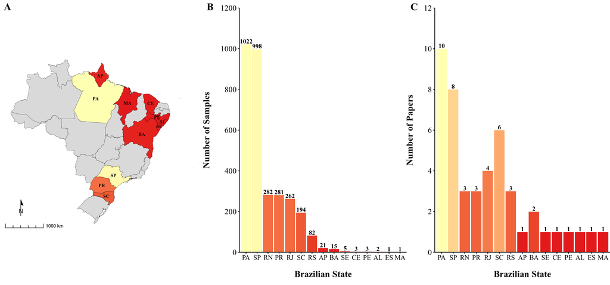

```r
plot(map_comp)
```

# Figure 3

```r
techs_by_year <- read.csv("../data/07_techs_by_year.csv")
marker_data <- read.csv("../data/08c_marker_data.csv")
mol_data <- read.csv("../data/02c_clean_gen_data.csv")
```

The four plots of Figure 3 are drawn separated:

```r
# Grouped bars plot
tech_types_plot <- techs_by_year %>%
  ggplot(aes(factor(publication_date), tech_count, fill = dna_technique)) +
  geom_bar(stat = "identity", position = "fill") +
  scale_y_continuous(labels = scales::percent, expand = c(0, 0)) +
  scale_fill_discrete(type = pal_pink) +
  labs(
    fill = "Technique",
    x = "\nPublication Date", y = "Percentage\n"
  ) +
  theme_minimal() +
  theme(
    panel.grid.major = element_blank(),
    panel.grid.minor = element_blank(),
    axis.line = element_line(color = "black"),
    axis.ticks = element_line(color = "black"),
    axis.title = element_text(face = "bold", size = 18, family = "Times New Roman"),
    axis.text = element_text(size = 16, family = "Times New Roman", color = "black"),
    legend.title = element_text(face = "bold", size = 14, family = "Times New Roman"),
    legend.text = element_text(size = 14, family = "Times New Roman"),
    legend.position = "right",
    plot.margin = margin(0.5, 0, 0.5, 0.5, "cm")
  )
```

```r
# Single bars plot
shark_plot <- ggplot(data = marker_data, aes(reorder(marker, percent), -percent, fill = species)) +
  geom_col(data = subset(marker_data, species == "shark"), position = "identity") +
  geom_text(
    data = subset(marker_data, species == "shark"), aes(label = sp_count),
    vjust = 0.5, hjust = -0.5, size = 3
  ) +
  scale_x_discrete(position = "top") +
  scale_y_continuous(labels = function(x) scales::percent(abs(x), scale = 1), expand = c(0, 3)) +
  scale_fill_manual(values = "grey55") +
  coord_flip() +
  labs(x = NULL, y = "\nPercent") +
  theme_minimal() +
  theme(
    axis.title = element_text(face = "bold", size = 18, family = "Times New Roman", color = "black"),
    axis.text.y = element_blank(),
    axis.text.x = element_text(size = 14, family = "Times New Roman", color = "black"),
    axis.line.x = element_line(color = "black"),
    axis.ticks.x = element_line(color = "black"),
    legend.position = "none"
  )

## Define y axis limits
y_limits <- c("Mitochondrial Genome", "ITS2", "CytB", "12S", "16S", "ND2", "COI", "COI (BOLD)")

plot_labels <- ggplot(data = marker_data, aes(reorder(marker, percent), -percent, fill = species)) +
  geom_col(
    data = subset(marker_data, species == "shark"),
    aes(reorder(marker, percent), 0, fill = alpha("white", 0)),
    position = "identity"
  ) +
  geom_text(aes(y = 0, label = as.character(marker)), size = 3.5) +
  scale_x_discrete(limits = y_limits) +
  coord_flip() +
  labs(x = NULL, y = NULL) +
  theme_minimal() +
  theme(
    legend.position = "none",
    axis.text = element_blank(),
    axis.ticks = element_blank(),
    panel.grid = element_blank(),
    # plot.margin = margin(0.25, 0, 1.07, 0, "cm")
    plot.margin = margin(0.15, 0.5, 1.7, 0.5, "cm")
  )

ray_plot <- ggplot(data = marker_data, aes(reorder(marker, percent), -percent, fill = species)) +
  geom_col(data = subset(marker_data, species == "ray"), position = "identity") +
  geom_text(
    data = subset(marker_data, species == "ray"), aes(label = sp_count),
    vjust = 0.5, hjust = 1.5, size = 2.75
  ) +
  scale_x_discrete(position = "top") +
  scale_y_continuous(
    labels = function(x) scales::percent(abs(x), scale = 1), expand = c(0, 3),
    trans = "reverse"
  ) +
  scale_fill_manual(values = "grey55") +
  coord_flip() +
  labs(x = NULL, y = "\nPercent") +
  theme_minimal() +
  theme(
    axis.title = element_text(face = "bold", size = 18, family = "Times New Roman", color = "black"),
    axis.text.y = element_blank(),
    axis.text.x = element_text(size = 14, family = "Times New Roman", color = "black"),
    legend.position = "none",
    axis.line.x = element_line(color = "black"),
    axis.ticks.x = element_line(color = "black")
  )

# Create composite plot
markers_plot <- ggarrange(shark_plot, plot_labels, ray_plot,
  ncol = 3,
  widths = c(1, 0.35, 1)
)
# Donut plot
# Define marker vector names
marker_columns <- c("marker_coi", "marker_cytb", "marker_12s", "marker_16s", "marker_nadh2", "marker_its2", "marker_mitogenome", "marker_bold_coi")

# Filter the dataset
mol_data_filter <- mol_data %>%
  slice(-c(46, 49, 51, 64)) %>%
  mutate(across(all_of(marker_columns), ~ replace_na(., 0))) %>%
  mutate(
    geo_distribution = str_replace(geo_distribution, "endemic", "Brazil"),
    geo_distribution = str_replace(geo_distribution, "wide-range", "Wide range")
  ) %>%
  filter(geo_distribution %in% c("Brazil", "Wide range"))

# Extract counts and percentages
mol_data_filter <- mol_data_filter %>%
  group_by(geo_distribution) %>%
  summarise(across(all_of(marker_columns), ~ sum(.x > 0 & !is.na(.x))))

mol_data_filter <- mol_data_filter %>%
  pivot_longer(cols = starts_with("marker"), names_to = "marker", values_to = "count") %>%
  mutate(percentage = round((count / 57) * 100, 0))

techs_br <- mol_data_filter %>%
  filter(geo_distribution == "Brazil")

techs_wr <- mol_data_filter %>%
  filter(geo_distribution == "Wide range")

# Create donut plots
techs_br_plot <- ggplot(techs_br, aes(x = 2, y = percentage, fill = marker)) +
  geom_bar(stat = "identity") +
  geom_text(aes(label = paste0("", count)),
    position = position_stack(vjust = 0.5),
    size = 3
  ) +
  coord_polar("y", start = 0) +
  xlim(.2, 2.5) +
  theme_void() +
  theme(
    panel.grid.major = element_blank(),
    panel.grid.minor = element_blank(),
    axis.line = element_blank(),
    axis.ticks = element_blank(),
    axis.title = element_blank(),
    axis.text = element_blank(),
    legend.position = "none",
    plot.margin = margin(0, -1.5, 0, -1.5, "cm")
  )

techs_wr_plot <- ggplot(techs_wr, aes(x = 2, y = percentage, fill = marker)) +
  geom_bar(stat = "identity") +
  geom_text(aes(label = paste0("", count)),
    position = position_stack(vjust = 0.5),
    size = 3
  ) +
  coord_polar("y", start = 0) +
  xlim(.2, 2.5) +
  theme_void() +
  theme(
    panel.grid.major = element_blank(),
    panel.grid.minor = element_blank(),
    axis.line = element_blank(),
    axis.ticks = element_blank(),
    axis.title = element_blank(),
    axis.text = element_blank(),
    legend.position = "none",
    plot.margin = margin(0, -1.5, 0, -1.5, "cm")
  )

techs_br_wr <- ggarrange(techs_br_plot, techs_wr_plot,
  nrow = 2
)
```

```r
# Lollipop plot

## Extract distribution data
distrib_data <- mol_data %>%
  slice(-c(46, 49, 51, 64)) %>%
  group_by(geo_distribution) %>%
  summarise(distribution = n())

## Edit dataframe change text
distrib_data <- distrib_data %>%
  mutate(
    geo_distribution = str_replace(geo_distribution, "endemic", "Brazil"),
    geo_distribution = str_replace(geo_distribution, "wide-range", "Wide range")
  ) %>%
  slice(-1) # remove Latin America

# Lollipop plot
distrib_plot <- ggplot(distrib_data, aes(geo_distribution, distribution)) +
  geom_point() +
  geom_segment(aes(geo_distribution, xend = geo_distribution, y = 0, yend = distribution)) +
  scale_y_continuous(
    limits = c(0, 50),
    breaks = seq(0, 50, 10),
    expand = c(0, 0)
  ) +
  labs(x = "\nGeographic Distribution", y = "Number of Species\n") +
  theme_minimal() +
  theme(
    panel.grid.major = element_blank(),
    panel.grid.minor = element_blank(),
    axis.line = element_line(color = "black"),
    axis.ticks = element_line(color = "black"),
    axis.title = element_text(face = "bold", size = 18, family = "Times New Roman"),
    axis.text = element_text(size = 16, family = "Times New Roman", color = "black"),
    legend.title = element_text(face = "bold", size = 14, family = "Times New Roman"),
    legend.text = element_text(size = 14, family = "Times New Roman"),
    legend.position = "bottom",
    legend.justification = "center"
  )
```

The final composition of Figure 3 is then drawn:

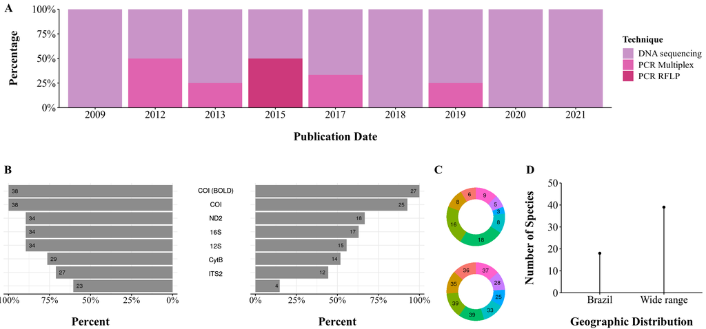

```r
tech_markers_comp <- ggarrange(tech_types_plot,
  nrow = 3, labels = "A",
  NULL,
  ggarrange(markers_plot, techs_br_wr, distrib_plot,
    ncol = 3,
    labels = c("B", "C", "D"),
    widths = c(3.5, 0.75, 1.5),
    vjust = -0.75,
    font.label = list(
      size = 18,
      family = "Times New Roman"
    )
  ),
  font.label = list(size = 18, family = "Times New Roman"),
  heights = c(1, 0.20, 1)
)

plot(tech_markers_comp)
```

# Figure 4

```r
# Count genus by samples and papers
sample_genus <- clean_data %>%
  group_by(genus) %>%
  summarise(s_count = n()) %>%
  arrange(desc(s_count)) %>%
  drop_na()

paper_genus <- clean_data %>%
  group_by(genus) %>%
  summarise(p_count = n_distinct(paper)) %>%
  arrange(desc(p_count)) %>%
  drop_na()

s_genus_plot <- sample_genus %>%
  ggplot(aes(reorder(genus, s_count), s_count)) +
  geom_bar(stat = "identity", aes(fill = classification)) +
  geom_text(aes(label = s_count),
    hjust = -0.2,
    size = 4,
    family = "Times New Roman",
    fontface = "bold"
  ) +
  geom_text(aes(label = ifelse(genus %in% not_endang, "*", "")),
    vjust = "center",
    hjust = -4,
    nudge_x = -0.15,
    size = 4,
    family = "Times New Roman",
    fontface = "bold"
  ) +
  scale_fill_discrete(type = pal_pink) +
  scale_y_continuous(
    limits = c(0, 1000),
    breaks = seq(0, 1000, by = 200),
    expand = c(0, 0)
  ) +
  coord_flip() +
  labs(x = "\nGenus", y = "\nSample Count") +
  theme_minimal() +
  theme(
    panel.grid.major = element_blank(),
    panel.grid.minor = element_blank(),
    legend.position = "none",
    axis.line = element_line(color = "black"),
    axis.ticks = element_line(color = "black"),
    axis.title = element_text(face = "bold", size = 18),
    axis.text.x = element_text(size = 12, color = "black"),
    axis.text.y = element_text(size = 12, color = "black", face = "italic"),
    text = element_text(family = "Times New Roman"),
    plot.margin = margin(0.5, 0.5, 0.5, 0.5, "cm")
  )


p_genus_plot <- paper_genus %>%
  ggplot(aes(reorder(genus, p_count), p_count)) +
  geom_bar(stat = "identity", aes(fill = classification)) +
  geom_text(aes(label = p_count),
    hjust = -0.2,
    size = 4,
    family = "Times New Roman",
    fontface = "bold"
  ) +
  geom_text(aes(label = ifelse(genus %in% not_endang, "*", "")),
    vjust = "center",
    hjust = -4,
    nudge_x = -0.15,
    size = 4,
    family = "Times New Roman",
    fontface = "bold"
  ) +
  scale_fill_discrete(type = pal_pink) +
  scale_y_continuous(
    limits = c(0, 20),
    breaks = seq(0, 20, by = 4),
    expand = c(0, 0)
  ) +
  coord_flip() +
  labs(x = NULL, y = "\nPaper Count") +
  theme_minimal() +
  theme(
    panel.grid.major = element_blank(),
    panel.grid.minor = element_blank(),
    legend.position = "none",
    axis.line = element_line(color = "black"),
    axis.ticks = element_line(color = "black"),
    axis.title = element_text(face = "bold", size = 18),
    axis.text.x = element_text(size = 12, color = "black"),
    axis.text.y = element_text(size = 12, color = "black", face = "italic"),
    text = element_text(family = "Times New Roman"),
    plot.margin = margin(0.5, 0.5, 0.5, 0.5, "cm")
  )
```

[output not shown]

# Figure 5

To map how IUCN statuses changed over the years, a jitter plot was created. Two mais plots were created: the first one represents species that changed two statuses since 2009; the second one represents species that were previously classified as data deficient and gained another classification through the years.

```r
# Load dataset
iucn_data <- read.csv("../data/Metadata-EvolutionConservationStatus - definitiva (edit).csv")

# Define species vector names
st_chg_names <- c(
  "Aetobatus narinari", " + Carcharhinus acronotus", "* Fontitrygon geijskesi",
  "* Pseudobatos percellens", " + Rhizoprionodon porosus",
  "Sphyrna tiburo", "Sphyrna tudes"
)

dd_st_names <- c(
  "+ Carcharhimus porosus", "* Dasyatis hypostigma", "Ginglymostoma cirratum",
  "Gymnura altavela", "Hypanus americanus", "Hypanus dipterurus",
  "+ Hypanus guttatus", "Myliobatis freminvillei", "Myliobatis goodei",
  "* Narcine brasiliensis", "* Paratrygon aiereba", "* Potamotrygon motoro",
  "Rhinoptera bonasus", "+ Rhizoprionodon lalandii", "Rhizoprionodon terraenovae",
  "Squalus cubensis", "Squalus mitsukurii"
)
```

```r
# Define vector with species names
bad_status_spp <- c(
  "Aetobatus narinari", "Carcharhinus acronotus", "Fontitrygon geijskesi",
  "Pseudobatos percellens", "Rhizoprionodon porosus", "Sphyrna tiburo",
  "Sphyrna tudes"
)

# Filter data
bad_status_data <- iucn_data[iucn_data$species %in% bad_status_spp, ]
```

```r
# Define vector with species names
new_stats_spp <- c(
  "Carcharhimus porosus", "Dasyatis hypostigma", "Ginglymostoma cirratum",
  "Gymnura altavela", "Hypanus americanus", "Hypanus dipterurus",
  "Hypanus guttatus", "Myliobatis freminvillei", "Myliobatis goodei",
  "Narcine brasiliensis", "Paratrygon aiereba", "Potamotrygon motoro",
  "Rhinoptera bonasus", "Rhizoprionodon lalandii", "Rhizoprionodon terraenovae",
  "Squalus cubensis", "Squalus mitsukurii"
)

# Filter data
new_stats_data <- iucn_data[iucn_data$species %in% new_stats_spp, ]
```

The jitter plot was constructed based on the `geom_jitter`, with each dot painted with the color that represents a IUCN status, based on the IUCN color palette.

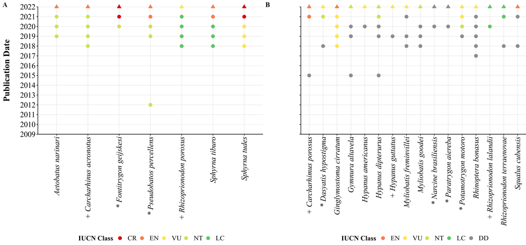

```r
# Create plots
status_change_plot <- ggplot(bad_status_data, aes(species, year, color = iucn_global)) +
  geom_jitter(width = -30, height = -15, aes(shape = class), size = 3) +
  guides(shape = "none") +
  scale_y_continuous(
    limits = c(2009, 2022),
    breaks = seq(2009, 2022, 1),
    expand = c(0, 0)
  ) +
  scale_x_discrete(
    guide = guide_axis(angle = 90),
    labels = st_chg_names
  ) +
  scale_color_discrete(
    type = pal_st_chg,
    breaks = c("CR", "EN", "VU", "NT", "LC", "DD", "NE")
  ) +
  guides(color = guide_legend(nrow = 1)) +
  scale_shape_manual(values = c(19, 17)) +
  coord_cartesian(clip = "off") +
  labs(x = NULL, y = "Publication Date\n", color = "IUCN Class") +
  theme_minimal() +
  theme(
    panel.grid.major = element_line(),
    panel.grid.minor = element_blank(),
    axis.line = element_line(color = "black"),
    axis.ticks = element_line(color = "black"),
    axis.text.x = element_text(
      face = "italic", family = "Times New Roman",
      size = 16, color = "black"
    ),
    axis.text.y = element_text(family = "Times New Roman", size = 16, color = "black"),
    axis.title.y = element_text(face = "bold", family = "Times New Roman", size = 18),
    legend.text = element_text(family = "Times New Roman", size = 14, color = "black"),
    legend.title = element_text(face = "bold", family = "Times New Roman", size = 14),
    legend.justification = "center",
    legend.position = "bottom",
    plot.margin = unit(c(0.5, 0, 0, 0.25), "cm")
  )

dd_status_plot <- ggplot(new_stats_data, aes(species, year, color = iucn_global)) +
  geom_jitter(width = -30, height = -15, aes(shape = class), size = 3) +
  guides(shape = "none") +
  scale_y_continuous(
    limits = c(2009, 2022),
    breaks = seq(2009, 2022, 1),
    expand = c(0, 0)
  ) +
  scale_x_discrete(
    guide = guide_axis(angle = 90),
    labels = dd_st_names
  ) +
  scale_color_discrete(
    type = pal_st_dd,
    breaks = c("CR", "EN", "VU", "NT", "LC", "DD", "NE")
  ) +
  guides(color = guide_legend(nrow = 1)) +
  scale_shape_manual(values = c(19, 17)) +
  coord_cartesian(clip = "off") +
  labs(x = NULL, y = NULL, color = "IUCN Class") +
  theme_minimal() +
  theme(
    panel.grid.major = element_line(),
    panel.grid.minor = element_blank(),
    axis.line = element_line(color = "black"),
    axis.ticks = element_line(color = "black"),
    axis.text.x = element_text(
      face = "italic", family = "Times New Roman",
      size = 16, color = "black"
    ),
    # axis.text.y = element_text(family = "Times New Roman", size = 9),
    axis.text.y = element_blank(),
    axis.title.y = element_text(face = "bold", family = "Times New Roman", size = 16),
    legend.text = element_text(family = "Times New Roman", size = 14, color = "black"),
    legend.title = element_text(face = "bold", family = "Times New Roman", size = 14),
    legend.justification = "center",
    legend.position = "bottom",
    plot.margin = unit(c(0.5, 0, 0, 0.25), "cm")
  )

iucn_comp_plot <- ggarrange(status_change_plot, dd_status_plot,
  labels = c("A", "B"), ncol = 2,
  heights = c(1, 1), align = "hv", font.label = list(size = 14, family = "Times New Roman")
)

plot(iucn_comp_plot)
```

# Figure 6

```r
# Load dataset
threat_data <- as_tibble(readxl::read_xlsx(
  "../data/SupportingInformation03.xlsx",
  skip = 1
) %>%
  filter(!row_number() %in% 1))
```

We included status abbreviations based on the IUCN classification and separated each assessment, creating the dataframes `threat_data_iucn` and `threat_data_br`.

```r
# Abbreviate threat status
threat_data <- threat_data %>%
  mutate(across(everything(), ~ replace(., . == "Critically Endangered", "CR"))) %>%
  mutate(across(everything(), ~ replace(., . == "Data Deficient", "DD"))) %>%
  mutate(across(everything(), ~ replace(., . == "Endangered", "EN"))) %>%
  mutate(across(everything(), ~ replace(., . == "Endangered/Least Concern", "EN/LC"))) %>%
  mutate(across(everything(), ~ replace(., . == "Least Concern", "LC"))) %>%
  mutate(across(everything(), ~ replace(., . == "Near Threatened", "NT"))) %>%
  mutate(across(everything(), ~ replace(., . == "Vulnerable", "VU"))) %>%
  mutate(across(everything(), ~ replace(., . == "na", NA)))

# Create new dataframes
iucn_global <- threat_data %>%
  count(`IUCN - Global`) %>%
  rename(
    status = `IUCN - Global`,
    total = n
  ) %>%
  mutate(origin = "IUCN Global")

iucn_sa <- threat_data %>%
  count(`IUCN - Southwest Atlantic`) %>%
  rename(
    status = `IUCN - Southwest Atlantic`,
    total = n
  ) %>%
  mutate(origin = "IUCN Southwest Atlantic")

br_redbook <- threat_data %>%
  count(`Brazil - RedBook`) %>%
  rename(
    status = `Brazil - RedBook`,
    total = n
  ) %>%
  mutate(origin = "Brazil Red Book")

br_2009 <- threat_data %>%
  count(`Brazil - IN 05/2009`) %>%
  rename(
    status = `Brazil - IN 05/2009`,
    total = n
  ) %>%
  mutate(origin = "Brazil IN 05/2009")

br_2014 <- threat_data %>%
  count(`Brazil -  MMA 445/2014`) %>%
  rename(
    status = `Brazil -  MMA 445/2014`,
    total = n
  ) %>%
  mutate(origin = "Brazil MMA 445/2014")

br_2023 <- threat_data %>%
  count(`Brazil - MMA 354/2023`) %>%
  rename(
    status = `Brazil - MMA 354/2023`,
    total = n
  ) %>%
  mutate(origin = "Brazil MMA 354/2023")

br_salve <- threat_data %>%
  count(`Brazil - SALVE System`) %>%
  rename(
    status = `Brazil - SALVE System`,
    total = n
  ) %>%
  mutate(origin = "Brazil SALVE System")

# Create status dataframes
status_data <- rbind(iucn_global, br_redbook, br_2014, br_2023, br_salve)
threat_data_iucn <- rbind(iucn_global, iucn_sa, br_redbook)
threat_data_br <- rbind(br_2009, br_2014, br_2023, br_salve)
```

Minor factor level adjustments were performed to better reflect how the assessments were performed over the years.

```r
# Adjust column levels
threat_data_iucn$origin <- factor(threat_data_iucn$origin,
  levels = c("Brazil Red Book", "IUCN Southwest Atlantic", "IUCN Global")
)

threat_data_iucn$status <- factor(threat_data_iucn$status,
  levels = c("CR", "EN", "VU", "NT", "LC", "DD", "NA")
)

threat_data_br$origin <- factor(threat_data_br$origin,
  levels = c(
    "Brazil SALVE System", "Brazil MMA 354/2023",
    "Brazil MMA 445/2014", "Brazil IN 05/2009"
  )
)

threat_data_br$status <- factor(threat_data_br$status,
  levels = c("CR", "EN", "VU", "NT", "LC", "DD", "Anexo I", "Anexo II", "NA")
)
```

Finally, the plots are created and the final composition is achieved.

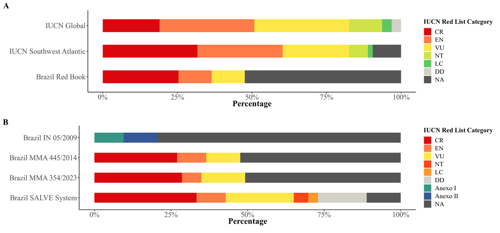

```r
threat_plot <- ggplot(threat_data_iucn, aes(origin, total, fill = status)) +
  geom_bar(stat = "identity", position = position_fill(reverse = TRUE), width = 0.5) +
  coord_flip() +
  scale_y_continuous(labels = scales::label_percent()) +
  scale_fill_manual(values = pal_threat, na.value = "#555555") +
  labs(x = "", y = "Percentage", fill = "IUCN Red List Category") +
  theme_minimal() +
  theme(
    panel.grid.major = element_blank(),
    panel.grid.minor = element_blank(),
    axis.line = element_line(color = "black"),
    axis.ticks = element_line(color = "black"),
    axis.title = element_text(family = "Times New Roman", size = 18, face = "bold"),
    axis.text.x = element_text(family = "Times New Roman", size = 16),
    axis.text.y = element_text(family = "Times New Roman", size = 16),
    legend.text = element_text(family = "Times New Roman", size = 14),
    legend.title = element_text(face = "bold", family = "Times New Roman", size = 14),
    aspect.ratio = 1 / 4
  )

br_threat_plot <- ggplot(threat_data_br, aes(origin, total, fill = status)) +
  geom_bar(stat = "identity", position = position_fill(reverse = TRUE), width = 0.5) +
  coord_flip() +
  scale_y_continuous(labels = scales::label_percent()) +
  scale_fill_manual(values = pal_br_threat, na.value = "#555555") +
  labs(x = "", y = "Percentage", fill = "IUCN Red List Category") +
  theme_minimal() +
  theme(
    panel.grid.major = element_blank(),
    panel.grid.minor = element_blank(),
    axis.line = element_line(color = "black"),
    axis.ticks = element_line(color = "black"),
    axis.title = element_text(family = "Times New Roman", size = 18, face = "bold"),
    axis.text.x = element_text(family = "Times New Roman", size = 16),
    axis.text.y = element_text(family = "Times New Roman", size = 16),
    legend.text = element_text(family = "Times New Roman", size = 14),
    legend.title = element_text(face = "bold", family = "Times New Roman", size = 14),
    aspect.ratio = 1 / 4
  )

# Final composition
iucn_classification_comp <- ggarrange(threat_plot, br_threat_plot,
  nrow = 2, labels = c("A", "B"),
  font.label = list(
    size = 18,
    family = "Times New Roman"
  )
)
plot(iucn_classification_comp)
```

# Closing Remarks

All codes presented in this R Markdown file were written and revised throughout the development of the paper. We took special care to ensure code readability and reproducibility, structuring code in a linear, continuum process. We understand that packages and file locations may change and break the code. In this context, we urge the reader to carefully read the code and run it in a “line by line” fashion, ensuring that each part runs and its results can be directed further down the pipeline of all analysis.